# AI Audit Mini Consulting Project

Phillip Dong

## Set-up

```r
# Load necessary libraries
library(tidyverse)
library(dplyr)
```

```r
# Reading data into respective data frame for each phase
phase_1.df <- read.csv("2022-phase1-new-grad-applicants.csv")
phase_2.df <- read.csv("2022-phase2-new-grad-applicants.csv")
phase_3.df <- read.csv("2022-phase3-new-grad-applicants.csv")
final_hires.df <- read.csv("2022-final-hires-newgrad.csv")

# Phase 3 is untidy data, so transform into tidy data
phase_3.df <- phase_3.df %>%
    pivot_longer(-applicant_id,
               names_to="applicant_id_unique",
               values_to="rating") %>% # Transform row data into column attribute data
  pivot_wider(names_from=applicant_id,
              values_from=rating) %>%  # Create attribute columns
  separate(applicant_id_unique,
           sep=1,
           into=c("prefix","applicant_id")) %>% # Separate prefix from id
  subset(select=-prefix) %>% # Removing
  transform(applicant_id=as.integer(applicant_id)) # Convert id column from char to int

# Seeing if ids from Phase 1 is in subsequent phases, indicating a pass or fail for said phase
phase_1.df <- phase_1.df %>%
  mutate(phase_1=ifelse(phase_1.df$applicant_id %in% phase_2.df$applicant_id,"Pass","Fail")) %>%
  mutate(phase_2=ifelse(phase_1.df$applicant_id %in% phase_3.df$applicant_id,"Pass","Fail")) %>%
  mutate(phase_3=ifelse(phase_1.df$applicant_id %in% final_hires.df$applicant_id,"Pass","Fail"))

# Join all dataframes together
hires_info <- phase_1.df %>%
  left_join(phase_2.df, join_by(applicant_id, team_applied_for, cover_letter, cv, gpa, gender, extracurriculars, work_experience)) %>%
  left_join(phase_3.df, join_by(applicant_id)) %>%
  mutate_all(~replace_na(.,0)) # Fill NA's with 0
```

| applicant_id | team_applied_for | cover_letter | cv | gpa | gender | extracurriculars | work_experience | phase_1 | phase_2 | phase_3 | technical_skills | writing_skills | leadership_presence | speaking_skills | interviewer_rating_1 | interviewer_rating_2 |
| --- | --- | --- | --- | --- | --- | --- | --- | --- | --- | --- | --- | --- | --- | --- | --- | --- |
| 1010 | Software | 0 | 1 | 1.3 | Man | 1 | 1 | Fail | Fail | Fail | 0 | 0 | 0 | 0 | 0 | 0 |
| 1020 | Software | 0 | 1 | 3.4 | Woman | 2 | 1 | Fail | Fail | Fail | 0 | 0 | 0 | 0 | 0 | 0 |
| 1030 | Data | 1 | 1 | 2.4 | Woman | 2 | 0 | Pass | Fail | Fail | 56 | 16 | 5 | 2 | 0 | 0 |
| 1040 | Software | 0 | 1 | 2.7 | Man | 1 | 1 | Fail | Fail | Fail | 0 | 0 | 0 | 0 | 0 | 0 |
| 1050 | Data | 1 | 0 | 2.1 | Prefer not to say | 0 | 1 | Fail | Fail | Fail | 0 | 0 | 0 | 0 | 0 | 0 |
| 1060 | Software | 0 | 1 | 2.6 | Prefer not to say | 1 | 1 | Fail | Fail | Fail | 0 | 0 | 0 | 0 | 0 | 0 |
| 1070 | Software | 1 | 1 | 3.4 | Woman | 1 | 1 | Pass | Fail | Fail | 80 | 37 | 1 | 3 | 0 | 0 |
| 1080 | Data | 1 | 1 | 2.6 | Man | 1 | 1 | Pass | Fail | Fail | 89 | 48 | 0 | 4 | 0 | 0 |
| 1090 | Data | 1 | 1 | 3.7 | Man | 2 | 1 | Pass | Fail | Fail | 54 | 60 | 3 | 1 | 0 | 0 |
| 1100 | Software | 0 | 1 | 2.6 | Woman | 1 | 1 | Fail | Fail | Fail | 0 | 0 | 0 | 0 | 0 | 0 |

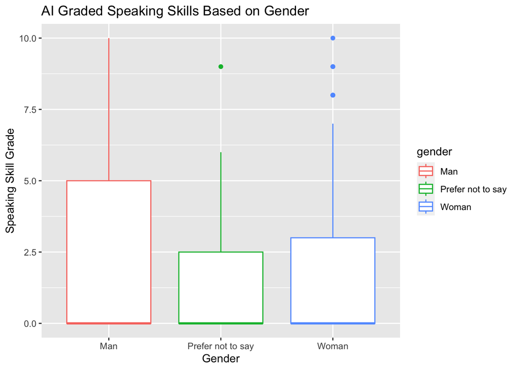

```r
# Plot speaking skill grading against each gender
hires_info %>%
  ggplot(aes(x=gender, y=speaking_skills, color=gender)) +
  geom_boxplot() +
  labs(
    title = "AI Graded Speaking Skills Based on Gender",
    x = "Gender",
    y = "Speaking Skill Grade",
    alt = "Box plot of speaking skill grades for each gender where the visual distribution for the speaking skill of a female, as graded by AI, is on average one grade lower than that of a male. (Link to data is not provided due to company ownership)"
  )
```

```r
# Summarize speaking skill of each gender
speak_sum <- hires_info %>%
  group_by(gender) %>%
  summarise(
    count = n(),
    mean = mean(speaking_skills, na.rm = TRUE),
    sd = sd(speaking_skills, na.rm = TRUE))

speak_sum
```

```
## # A tibble: 3 × 4
##   gender            count  mean    sd
##   <chr>             <int> <dbl> <dbl>
## 1 Man                 291  2.53  3.05
## 2 Prefer not to say    11  1.82  3.25
## 3 Woman               311  1.62  2.19
```

```r
# Compute the analysis of variance for speaking_skills
speak.aov <- aov(speaking_skills ~ gender, hires_info)

# Summary of the analysis
summary(speak.aov)
```

```
##              Df Sum Sq Mean Sq F value  Pr(>F)
## gender        2    126   62.81   8.936 0.00015 ***
## Residuals   610   4288    7.03
## ---
## Signif. codes:  0 '***' 0.001 '**' 0.01 '*' 0.05 '.' 0.1 ' ' 1
```

```r
# Comparison of group means
TukeyHSD(speak.aov)
```

```
##   Tukey multiple comparisons of means
##     95% family-wise confidence level
##
## Fit: aov(formula = speaking_skills ~ gender, data = hires_info)
##
## $gender
##                               diff       lwr       upr     p adj
## Prefer not to say-Man   -0.7110278 -2.624263  1.202207 0.6574692
## Woman-Man               -0.9118463 -1.419865 -0.403828 0.0000845
## Woman-Prefer not to say -0.2008185 -2.111812  1.710175 0.9669574
```

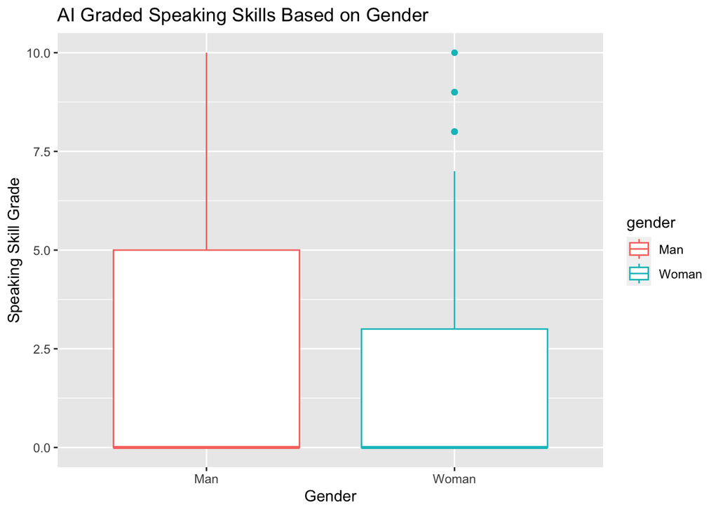

```r
# Remove prefer-not-to-say rows
hires_info <- subset(hires_info, gender != "Prefer not to say")

# Plot speaking skill grading against each gender
hires_info %>%
  ggplot(aes(x=gender, y=speaking_skills, color=gender)) +
  geom_boxplot() +
  labs(
    title = "AI Graded Speaking Skills Based on Gender",
    x = "Gender",
    y = "Speaking Skill Grade",
    alt = "Box plot of speaking skill grades for each gender where the visual distribution for the speaking skill of a female, as graded by AI, is on average one grade lower than that of a male. (Link to data is not provided due to company ownership)"
  )
```

```r
# Compute the analysis of variance for speaking_skills
speak.aov <- aov(speaking_skills ~ gender, hires_info)

# Summary of the analysis
summary(speak.aov)
```

```
##              Df Sum Sq Mean Sq F value   Pr(>F)
## gender        1    125  125.00   17.93 2.65e-05 ***
## Residuals   600   4182    6.97
## ---
## Signif. codes:  0 '***' 0.001 '**' 0.01 '*' 0.05 '.' 0.1 ' ' 1
```

```r
# Comparison of group means
TukeyHSD(speak.aov)
```

```
##   Tukey multiple comparisons of means
##     95% family-wise confidence level
##
## Fit: aov(formula = speaking_skills ~ gender, data = hires_info)
##
## $gender
##                 diff       lwr       upr    p adj
## Woman-Man -0.9118463 -1.334721 -0.488972 2.65e-05
```

From the statistical analysis of an applicant’s speaking skill as graded by the AI when grouped by gender, we can conclude that the means of female and male speech grades significantly differ when compared to pairwise comparison between other groups - such as female vs undisclosed gender, or male vs undisclosed gender. Population size for females and males are similar but after post-hoc analysis with Tukey’s test, we can see that on average, males are graded 0.911 points higher than females. For a given range, males are graded on average between 0.489 and 1.335 points than females. This is especially evident when addressing the graph, as we can observe that the upper quartile of speech grades for males is around 2 grades higher than the speech grades for females. The range of female grades are also around 3 grades lower than that of males. To the AI, males could appear to be more frequently eloquent due to preconceived data or because of a naturally deeper tone which is indicative of confidence. Therefore, it could be argued that the AI is being processed with biased training data.

An underlying risk of algorithmic bias is always prevalent when gender is involved in training Artificial Intelligence. For instance, a lack of representation of diverse genders in the data collection process can exacerbate selection bias as the voices of non-binary, or transgender individuals may not be adequately considered in the training data, which may influence the decisions made by the AI when grading the speaking skill of the applicant There are 11 applicants in the population that have undisclosed gender, and the spread of data for this group is the largest for all the genders, which could signify under-training of the AI. Therefore, the consideration of realistic and inclusive data representation is of utmost importance especially when considering ethical and legal reasons.